# Projekt modele liniowe i mieszane

### 4.1.2 Efekt losowy kraju

Podobnie, w naszych danych mamy tylko 5 krajów, więc podejrzewamy, że lepiej byłoby uwzględnić `id_kraju` jako zmienną losową.

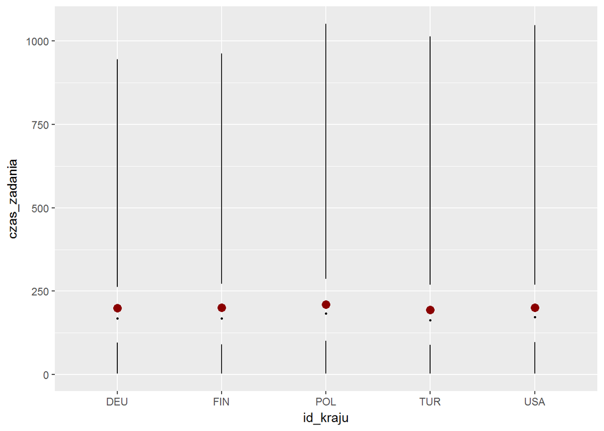

```r
sr_czas2 <- dane_nowe %>% group_by(id_kraju) %>% summarize(sr_czas2=mean(czas_zadania))
dane_nowe <- left_join(dane_nowe,sr_czas2, by="id_kraju")

ggplot(dane_nowe, aes(id_kraju, czas_zadania))+geom_tufteboxplot(median.type = NULL)+stat_summary(fun.x=sr_czas2$sr_czas2, colour="darkred", geom="point", size=3)
```

```r
model_kraj_staly <- lm(log(czas_zadania +45)~zadanie*pozycja_zadania+id_kwestionariusza+mies_ur+id_kraju*plec+wyk_m_lsd*wyk_o_lsd+gr_zawod_m+gr_zawod_o+stat_m+stat_o, data = dane_nowe)
```

```r
model_kraj_mieszany <- lmer(log(czas_zadania +45)~zadanie*pozycja_zadania+id_kwestionariusza+mies_ur+(1|id_kraju)*plec+wyk_m_lsd*wyk_o_lsd+gr_zawod_m+gr_zawod_o+stat_m+stat_o, data = dane_nowe, REML=F)
```

```r
df <- c(model_kraj_staly=BIC(model_kraj_staly),model_kraj_losowy=BIC(model_kraj_mieszany))
df
```

```
##  model_kraj_staly model_kraj_losowy
##          34454.46          34446.64
```

Podobnie jak dla zmiennej dotyczącej kwestionariusza, dodanie zmiennej `id_kraju` zmniejsza nam kryterium informacyjne.

```r
model_mieszany1 <- lmer(log(czas_zadania +45)~zadanie*pozycja_zadania+(1|id_kwestionariusza)+mies_ur+(1|id_kraju)*plec+wyk_m_lsd*wyk_o_lsd+gr_zawod_m+gr_zawod_o+stat_m+stat_o, data = dane_nowe, REML=F)
```

## 4.2 Nowe zmienne

Oprócz zmiennych rozważanych wcześniej chcemy dodać do modelu zmienne, które automatycznie nasuwają się na myśl gdy rozważamy te dane. Są to `id_ucznia` i `id_szkoly`.

### 4.2.1 Efekt losowy szkoły

Najpierw rozważamy model z efektem losowym dla szkoły.

```r
model_szkola <- lmer(log(czas_zadania +45)~zadanie*pozycja_zadania+(1|id_kwestionariusza)+mies_ur+(1|id_kraju)*plec+wyk_m_lsd*wyk_o_lsd+gr_zawod_m+gr_zawod_o+stat_m+stat_o+(1|id_szkoly), data = dane_nowe, REML=F)

BIC(model_szkola)
```

```
## [1] 31256.17
```

Widzimy, że dodanie szkoły jako efekt losowy polepsza nam kryterium informacyjne.

### 4.2.2 Efekt losowy ucznia

Model z efektem losowym ucznia.

```r
model_uczen <- lmer(log(czas_zadania +45)~zadanie*pozycja_zadania+(1|id_kwestionariusza)+mies_ur+(1|id_kraju)*plec+wyk_m_lsd*wyk_o_lsd+gr_zawod_m+gr_zawod_o+stat_m+stat_o+(1|id_szkoly)+(1|id_ucznia), data = dane_nowe, REML=F)

BIC(model_uczen)
```

```
## [1] 27158.1
```

### 4.2.3 Zagnieżdzone zmienne

Model z uczniem jako efektem zagnieżdzonym w szkole.

```r
model_uczen_szkola <- lmer(log(czas_zadania +45)~zadanie*pozycja_zadania+(1|id_kwestionariusza)+mies_ur+(1|id_kraju)*plec+wyk_m_lsd*wyk_o_lsd+gr_zawod_m+gr_zawod_o+stat_m+stat_o+(1|id_szkoly/id_ucznia), data = dane_nowe, REML=F)

BIC(model_uczen_szkola)
```

```
## [1] 27158.1
```

# 5 Istotność zmiennych w modelu

## 5.1 Efekty losowe

Ostateczny model różni się od przedstawionego w poprzedniej fazie dwoma zmiennymi: `id_szkoly` i `id_ucznia`. Zostały one uwzględnione jako efekty losowe. Zbadamy istotność wyżej wymienionych zmiennych oraz zmiennych używanych w poprzednim modelu, ale teraz zakwalifikowanych jako efekty losowe. Do oceny istotności efektów użyjemy testu ilorazu wiarogodności.

- `id_kwestionariusza`

```r
model<- lm(log(czas_zadania +45)~zadanie*pozycja_zadania+mies_ur+id_kraju*plec+wyk_m_lsd*wyk_o_lsd+gr_zawod_m+gr_zawod_o+stat_m+stat_o, data = dane_nowe)
x1 <- logLik(model)
x2 <- logLik(model_kwestionariusz_mieszany)
roznica <- as.numeric(x1-x2)

##36 efektow dla kwestionariusza


pchisq(-2*roznica,2302,lower.tail=FALSE)
```

```
## [1] 1
```

- `id_kraju`

```r
model<- lm(log(czas_zadania +45)~zadanie*pozycja_zadania+id_kwestionariusza+mies_ur+plec+wyk_m_lsd*wyk_o_lsd+gr_zawod_m+gr_zawod_o+stat_m+stat_o, data = dane_nowe)
x1 <- logLik(model)
x2 <- logLik(model_kraj_mieszany)
roznica <- as.numeric(x1-x2)

##5 efektow dla kraju

pchisq(-2*roznica,5,lower.tail=FALSE)
```

```
## [1] 2.044101e-11
```

Zmienna `id_kraju` jako efekt losowy jest istotna.

- `id_szkoly/id_ucznia`

```r
model <- lm(log(czas_zadania +45)~zadanie*pozycja_zadania+id_kwestionariusza+mies_ur+id_kraju*plec+wyk_m_lsd*wyk_o_lsd+gr_zawod_m+gr_zawod_o+stat_m+stat_o, data = dane_nowe)

model_uczen_szkola2 <- lmer(log(czas_zadania +45)~zadanie*pozycja_zadania+id_kwestionariusza+mies_ur+id_kraju*plec+wyk_m_lsd*wyk_o_lsd+gr_zawod_m+gr_zawod_o+stat_m+stat_o+(1|id_szkoly/id_ucznia), data = dane_nowe, REML=F)

x1 <- logLik(model)
x2 <- logLik(model_uczen_szkola2)
roznica <- as.numeric(x1-x2)

##2302 efekty dla szkoly i zagniezdzonego w nim ucznia


pchisq(-2*roznica,2302,lower.tail=FALSE)
```

```
## [1] 0
```

Zmienna `id_szkoly` i zagnieżdzona w niej zmienna `id_ucznia` też została uznana za istotną.

## 5.2 Efekty stałe

Istotność efektów stałych badaliśmy we wcześniejszych fazach i wszystkie zostały zawalifikowane jako istotne.

# 6 Analiza współczynników.

## 6.1 Rozkład efektów mieszanych

```r
u <- ranef(model_uczen_szkola,condVar=TRUE)
u_uczen_szkola <- data.frame(u$`id_ucznia:id_szkoly`$`(Intercept)`)
colnames(u_uczen_szkola) <- "uczen_szkola"

u_szkola <- data.frame(u$`id_szkoly`$`(Intercept)`)
colnames(u_szkola) <- "szkola"
```

Sprawdzimy, czy rozkłady efektów `id_szkoły` i `id_ucznia:id_szkoly`, ponieważ mamy dla nich wiele obserwacji, a tylko wtedy sensowne jest badanie rozkładu zmiennej.

Dla modelu mieszanego chcemy aby współczynniki `u` miały w przybliżeniu rozkład normalny.

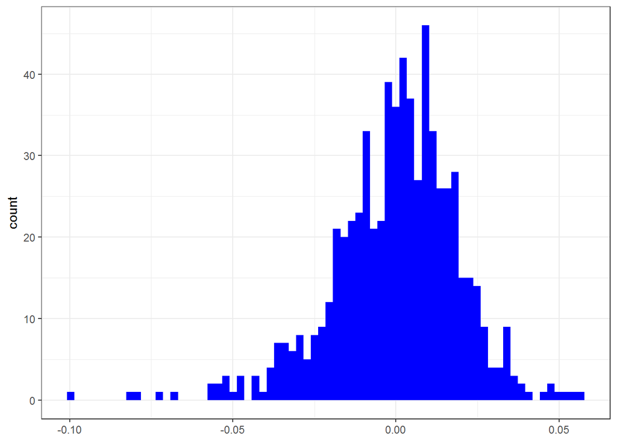

```r
ggplot(u_szkola, aes(szkola))+
  geom_histogram(bins=70, fill="blue")+
  theme_bw()+
  theme(axis.title.x =element_blank() )
```

```r
skewness(u_szkola$szkola)
```

```
## [1] -0.7331303
```

```r
kurtosis(u_szkola$szkola)
```

```
## [1] 2.08981
```

Powyższy rozkład jest bardziej skoncentrowany wokół średniej niż rozkład normalny. Skośność także odbiega od tej dla rozkładu normalnego.

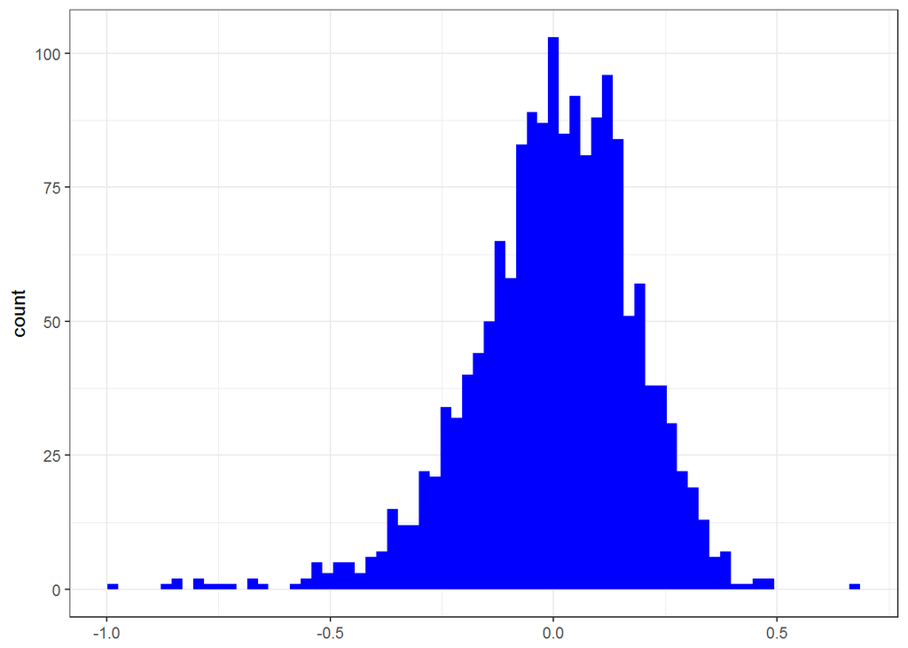

```r
ggplot(u_uczen_szkola, aes(uczen_szkola))+
  geom_histogram(bins=70, fill="blue")+
  theme_bw()+
  theme(axis.title.x =element_blank() )
```

```r
skewness(u_uczen_szkola$uczen_szkola)
```

```
## [1] -0.775377
```

```r
kurtosis(u_uczen_szkola$uczen_szkola)
```

```
## [1] 2.031914
```

Kurtoza i skośność mają podobne wartości jak dla rozkładu zmiennej `id_szkoly`.

## 6.2 Rozkład reszt modelu

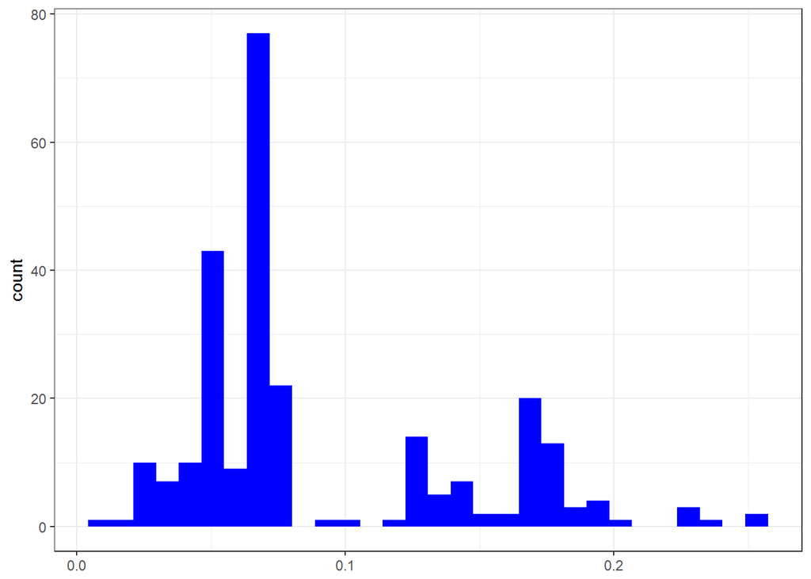

```r
podsumowanie<- summary(model_uczen_szkola)
epsilon <- podsumowanie$coefficient[,"Std. Error"]
epsilon <- as.data.frame(epsilon)

ggplot(epsilon, aes(epsilon))+
  geom_histogram(bins=30, fill="blue")+
  theme_bw()+
  theme(axis.title.x =element_blank() )
```

```r
skewness(epsilon$epsilon)
```

```
## [1] 1.028957
```

```r
kurtosis(epsilon$epsilon)
```

```
## [1] -0.03508549
```